# 607_FinalProject_StatisticalAnalysis

Santosh Cheruku, Priya Shaji

April 23, 2019

# Introduction

`'Medicine Recommender'` project is designed to work through the data set and identify if we can recommend a medicine to a patient based on the symptoms and the ratings and side effect info of it provided by the patients who previously consumed those drugs. Here, we are trying to identify if there is a statistical inference we can provide from the given data set of patients provided to us.

# Data

```r
train <- read_tsv("drugLibTrain_raw.tsv", col_names = TRUE, cols(
  X1 = col_double(),
  urlDrugName = col_character(),
  rating = col_double(),
  effectiveness = col_factor(),
  sideEffects = col_factor(),
  condition = col_factor(),
  benefitsReview = col_character(),
  sideEffectsReview = col_character(),
  commentsReview = col_character()
))

test <- read_tsv("drugLibTest_raw.tsv", col_names = TRUE, cols(
  X1 = col_double(),
  urlDrugName = col_character(),
  rating = col_double(),
  effectiveness = col_factor(),
  sideEffects = col_factor(),
  condition = col_factor(),
  benefitsReview = col_character(),
  sideEffectsReview = col_character(),
  commentsReview = col_character()
))

dataset <- full_join(train, test)
head(dataset)
```

```
## # A tibble: 6 x 9
##      X1 urlDrugName rating effectiveness sideEffects condition
##   <dbl> <chr>        <dbl> <chr>         <chr>       <chr>
## 1  2202 enalapril        4 Highly Effec~ Mild Side ~ manageme~
## 2  3117 ortho-tri-~      1 Highly Effec~ Severe Sid~ birth pr~
## 3  1146 ponstel         10 Highly Effec~ No Side Ef~ menstrua~
## 4  3947 prilosec         3 Marginally E~ Mild Side ~ acid ref~
## 5  1951 lyrica           2 Marginally E~ Severe Sid~ fibromya~
## 6  2372 propecia         1 Ineffective   Severe Sid~ hair loss
## # ... with 3 more variables: benefitsReview <chr>,
## #   sideEffectsReview <chr>, commentsReview <chr>
```

```r
dataset$effectiveness <- factor(dataset$effectiveness, levels=c('Ineffective','Marginally Effective','Moderately Effective','Considerably Effective','Highly Effective'))

dataset$sideEffects <- factor(dataset$sideEffects,levels=c('No Side Effects','Mild Side Effects','Moderate Side Effects','Severe Side Effects','Extremely Severe Side Effects'))
```

```r
## DataBase

#Process

#In Mysql

#1) create database Data607FinalProject
#2) set it as default schema
#3) import tables from the local file via Table Data Import Wizard

#In R

#1) Connect the Mysql database using dbConnect
#2) a) Case 1: if table exists, drop it
#   b) Case 2: Else create a new table

#3) Specify the column names and their #definition
#4) Write Query to update the tables
#5) Close Connection
CheckDB <- function() {

#--------------- Open Connection

  con2 <- dbConnect(RMySQL::MySQL(), dbname = "Data607FinalProject", host="localhost", user="root",password= "Sparc@DATA_607")
#--------------- Drop Table if Exists


if(dbExistsTable(con2, "dataset")){
    dbRemoveTable(con2,"dataset")

  }




#-------------- Create first table for dataset


query <- "CREATE TABLE `dataset` (
`Drug_id`  INT AUTO_INCREMENT,
`urlDrugName` VARCHAR(45) NULL,
`rating` VARCHAR(45) NULL,
`effectiveness` VARCHAR(45) NULL,
`sideEffects` VARCHAR(45) NULL,
`condition` VARCHAR(45) NULL,
`benefitsReview` VARCHAR(45) NULL,
`sideEffectsReview` VARCHAR(45) NULL,
`commentsReview` VARCHAR(45) NULL,
PRIMARY KEY (`Drug_id`))"
tab1 <- dbSendQuery(con2,query)
tab1data <- dbFetch(tab1)
#--------------- Close Connection
dbDisconnect(con2)
}
#--------------- Update tables
updateDB <- function(urlDrugName, rating, effectiveness, sideEffects, condition, benefitsReview, sideEffectsReview, commentsReview)
    {
  con2 <- dbConnect(RMySQL::MySQL(), dbname = "Data607FinalProject", host="localhost", user="root",password= "root")

#--------------- Update dataset table

query <- sprintf("insert into dataset (DrugName, Rating, Effectiveness, SideEffects, Condition, BenefitsReview, SideEffectsReview, CommentsReview) values('%s','%s','%s','%s','%s','%s','%s','%s')",urlDrugName, rating, effectiveness, sideEffects, condition, benefitsReview, sideEffectsReview, commentsReview)
  print (query)
tab1 <- dbSendQuery(con2,query)
tab1data <- dbFetch(tab1)
#--------------- Get 'Drug_id' to update dataset table
query <- sprintf("select Drug_id from dataset where DrugName='%s', Rating='%s', Effectiveness='%s', SideEffects='%s', Condition='%s', BenefitsReview='%s', SideEffectsReview='%s', CommentsReview='%s' limit 1",urlDrugName, rating, effectiveness, sideEffects, condition, benefitsReview, sideEffectsReview, commentsReview)

tab1 <- dbSendQuery(con2,query)
tab1data <- dbFetch(tab1)
data_id <- tab1data$Drug_id
#---------------- Close Connection
dbDisconnect(con2)
}
```

# Explorative Data Analysis

## Plotting drug effectiveness

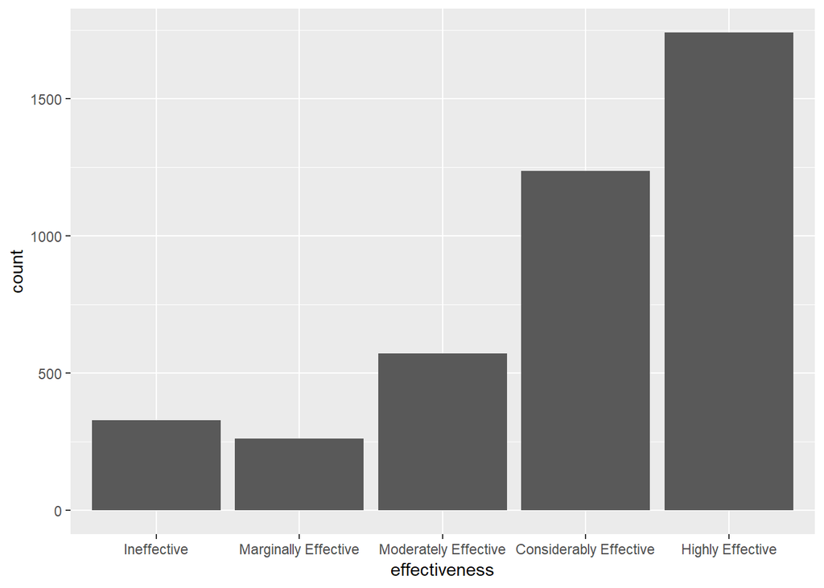

```r
ggplot(dataset, aes(x=effectiveness)) + geom_bar(stat="count")
```

## Plotting drug side effects for effectiveness

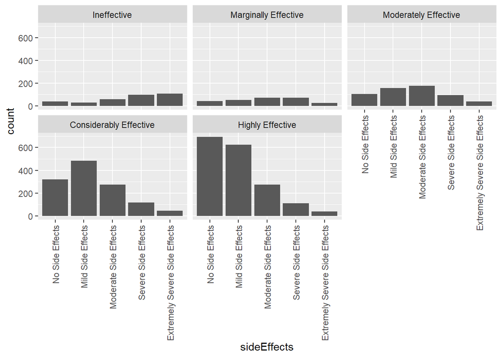

```r
ggplot(dataset, aes(x=sideEffects)) + geom_bar(stat="count") + facet_wrap(~effectiveness) + theme(axis.text.x=element_text(angle=90,hjust=1,vjust=0.5))
```

## Drug effectiveness vs Patient Rating

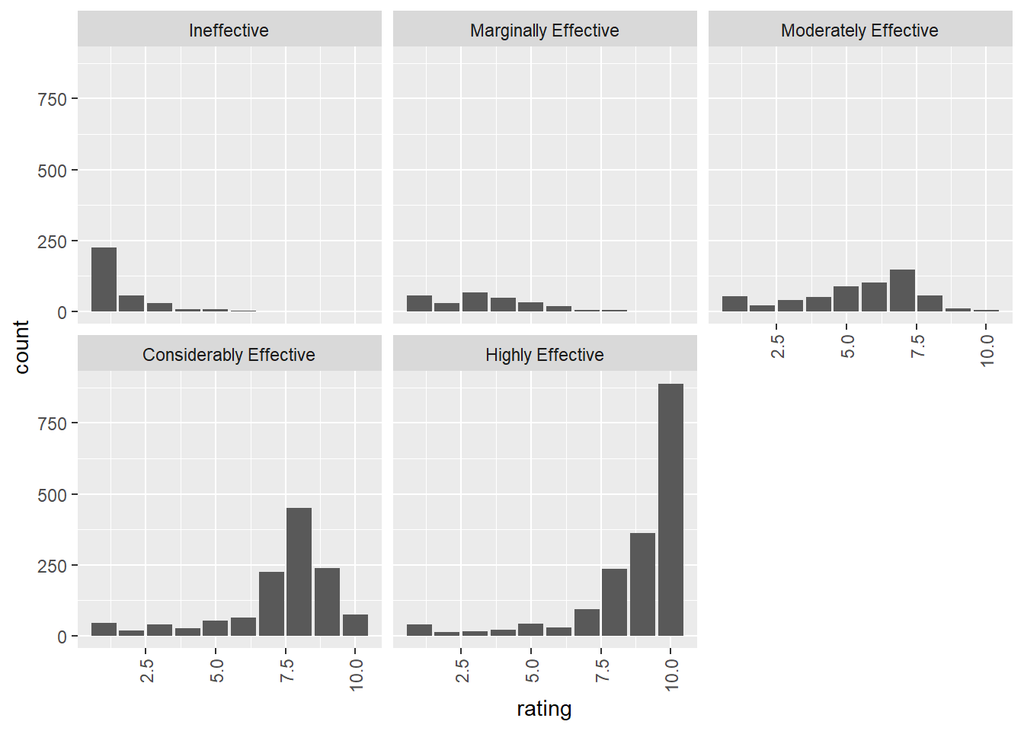

```r
ggplot(dataset, aes(x=rating)) + geom_bar(stat="count") + facet_wrap(~effectiveness) + theme(axis.text.x=element_text(angle=90,hjust=1,vjust=0.5))
```

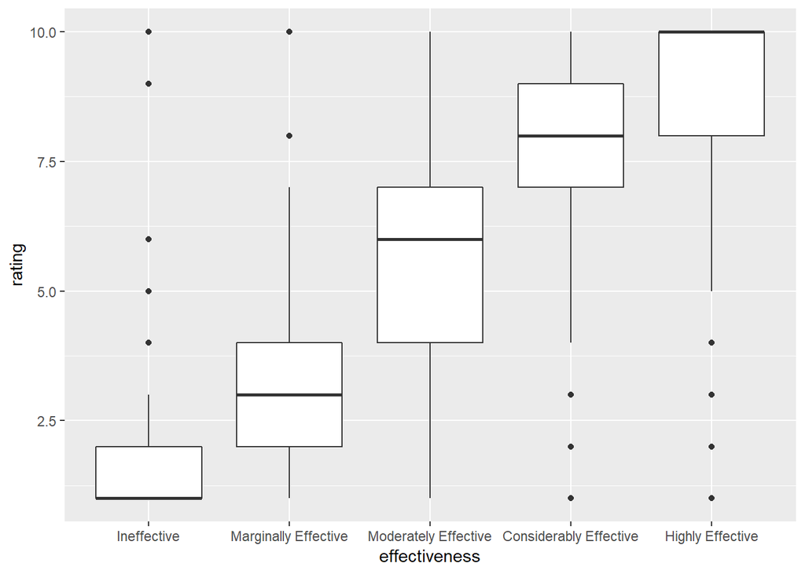

```r
ggplot(dataset, aes(x=effectiveness, rating)) + geom_boxplot()
```

## Distribution of patient ratings

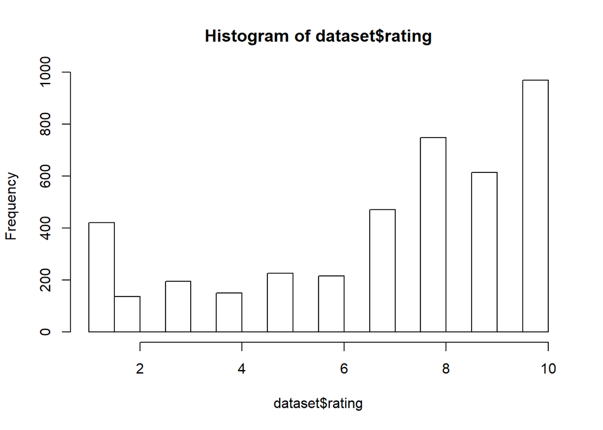

```r
hist(dataset$rating)
```

# Statistical Inference

```r
library(FSA)
Drugs_summary<-Summarize(dataset$rating ~ dataset$urlDrugName,,digits=3)

head(Drugs_summary)
```

```
##   dataset$urlDrugName  n  mean    sd min   Q1 median    Q3 max
## 1             abilify  8 5.375 2.875   2 2.75    6.0  6.50  10
## 2              acanya  1 9.000    NA   9 9.00    9.0  9.00   9
## 3            accolate  1 1.000    NA   1 1.00    1.0  1.00   1
## 4            accupril  1 9.000    NA   9 9.00    9.0  9.00   9
## 5            accutane 44 7.727 2.286   1 7.00    8.0  9.25  10
## 6             aciphex  6 8.833 1.602   6 8.25    9.5 10.00  10
```

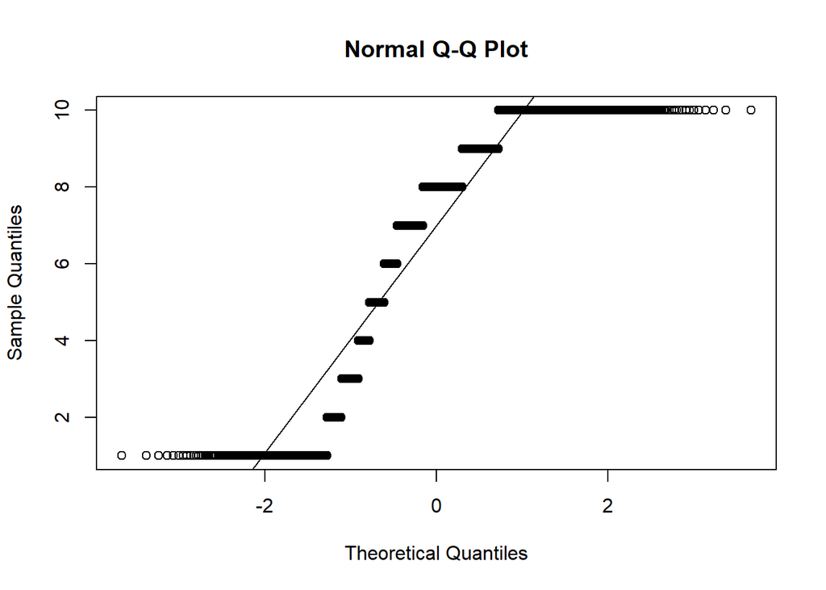

```r
qqnorm(dataset$rating)
qqline(dataset$rating)
```

From the above plots it is clear that the data distribution is not normal

## Calculate Confidence Interval

```r
highlyEffectiveDrugs <- subset(dataset, effectiveness=="Highly Effective")
noSideEffectDrugs <- subset(highlyEffectiveDrugs, sideEffects=='No Side Effects')

p<- nrow(noSideEffectDrugs)/nrow(highlyEffectiveDrugs)
n <- nrow(highlyEffectiveDrugs)


SE<- sqrt(p * (1-p)/n)

CILower <- p - 1.96 * SE
CIUpper <- p + 1.96 * SE
```